# Context and Defining Problem Statement

**Background:** AllLife Bank wants to focus on its credit card customer base in the next financial year. They have been advised by their marketing research team, that the penetration in the market can be improved. Based on this input, the Marketing team proposes to run personalised campaigns to target new customers as well as upsell to existing customers. Another insight from the market research was that the customers perceive the support services of the back poorly. Based on this, the Operations team wants to upgrade the service delivery model, to ensure that customers queries are resolved faster. Head of Marketing and Head of Delivery both decide to reach out to the Data Science team for help.  
**Objective:** To identify different segments in the existing customer based on their spending patterns as well as past interaction with the bank.

### Load necessary modules

```python
import numpy as np
import pandas as pd

import matplotlib.pyplot as plt
%matplotlib inline
import seaborn as sns
sns.set(color_codes=True) # adds a nice background to the graphs

import warnings
warnings.filterwarnings('ignore')

from sklearn.model_selection import train_test_split
from sklearn.cluster import KMeans

from scipy import stats
from scipy.stats import zscore
```

### Load data file and view top 10 rows

```python
ccdata = pd.read_excel('Credit Card Customer Data.xlsx', sheet_name='Sheet1', index_col=0)
ccdata.head(10)
```

| Sl_No | Customer Key | Avg_Credit_Limit | Total_Credit_Cards | Total_visits_bank | Total_visits_online | Total_calls_made |
| --- | --- | --- | --- | --- | --- | --- |
| 1 | 87073 | 100000 | 2 | 1 | 1 | 0 |
| 2 | 38414 | 50000 | 3 | 0 | 10 | 9 |
| 3 | 17341 | 50000 | 7 | 1 | 3 | 4 |
| 4 | 40496 | 30000 | 5 | 1 | 1 | 4 |
| 5 | 47437 | 100000 | 6 | 0 | 12 | 3 |
| 6 | 58634 | 20000 | 3 | 0 | 1 | 8 |
| 7 | 48370 | 100000 | 5 | 0 | 11 | 2 |
| 8 | 37376 | 15000 | 3 | 0 | 1 | 1 |
| 9 | 82490 | 5000 | 2 | 0 | 2 | 2 |
| 10 | 44770 | 3000 | 4 | 0 | 1 | 7 |

```python
# Let's check basic information about the data
ccdata.info()
```

```
<class 'pandas.core.frame.DataFrame'>
Int64Index: 660 entries, 1 to 660
Data columns (total 6 columns):
Customer Key           660 non-null int64
Avg_Credit_Limit       660 non-null int64
Total_Credit_Cards     660 non-null int64
Total_visits_bank      660 non-null int64
Total_visits_online    660 non-null int64
Total_calls_made       660 non-null int64
dtypes: int64(6)
memory usage: 36.1 KB
```

#### Onservations on dataset

1) Dataset contains 6 columns(features) ad 660 records(observations)  
2) First column is a pure key column  
3) Second and third column would help promote the campaign to gain more customers for credit cards  
4) Last three columns would help improve the customer service for the bank's customer

### 1. Perform univariate analysis on the data to better understand the variables at your disposal and to get an idea about the no of clusters. Perform EDA, create visualizations to explore data.

```python
# Check for missing value

ccdata.isna().sum().sum()                 #result shows no missing value
```

```
0
```

```python
# Check for correctness of data type
ccdata.dtypes                    # result shows that all datatype are correct. None of the column has incorrect values
```

```
Customer Key           int64
Avg_Credit_Limit       int64
Total_Credit_Cards     int64
Total_visits_bank      int64
Total_visits_online    int64
Total_calls_made       int64
dtype: object
```

```python
# Check for 5 key points
ccdata.describe()                   # Results are slef explanatory. We can notice the mean/min/max and other values
```

|  | Customer Key | Avg_Credit_Limit | Total_Credit_Cards | Total_visits_bank | Total_visits_online | Total_calls_made |
| --- | --- | --- | --- | --- | --- | --- |
| count | 660.000000 | 660.000000 | 660.000000 | 660.000000 | 660.000000 | 660.000000 |
| mean | 55141.443939 | 34574.242424 | 4.706061 | 2.403030 | 2.606061 | 3.583333 |
| std | 25627.772200 | 37625.487804 | 2.167835 | 1.631813 | 2.935724 | 2.865317 |
| min | 11265.000000 | 3000.000000 | 1.000000 | 0.000000 | 0.000000 | 0.000000 |
| 25% | 33825.250000 | 10000.000000 | 3.000000 | 1.000000 | 1.000000 | 1.000000 |
| 50% | 53874.500000 | 18000.000000 | 5.000000 | 2.000000 | 2.000000 | 3.000000 |
| 75% | 77202.500000 | 48000.000000 | 6.000000 | 4.000000 | 4.000000 | 5.000000 |
| max | 99843.000000 | 200000.000000 | 10.000000 | 5.000000 | 15.000000 | 10.000000 |

Data looks clean. No further imputation is required

```python
# Check for duplicate values
ccdata.duplicated().sum()                   # Result shows no duplicate values
```

```
0
```

### Perform Univariate analysis

```python
# Check frequency of each variable to see if there is any categorical column.
# Correct datatype to category, if needed.
ccdata.nunique()                 # Though Total_visit_bank shows 6 unique value but it is not categorical data
```

```
Customer Key           655
Avg_Credit_Limit       110
Total_Credit_Cards      10
Total_visits_bank        6
Total_visits_online     16
Total_calls_made        11
dtype: int64
```

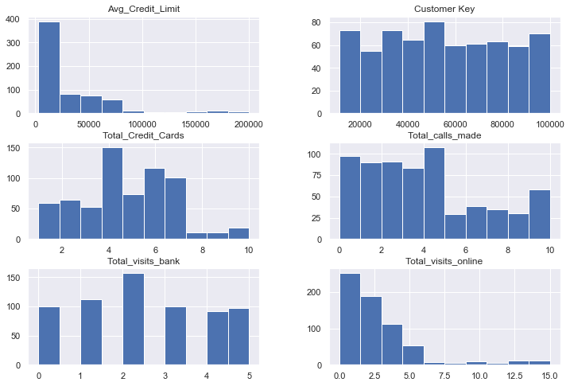

```python
# Generate bar charts for each variable to see the distribution pattern and skewness.
# Apply transformation (np.log()) to make data normally distributed

ccdata.hist(figsize=(12,40), layout=(14,2));
```

```python
# Let's measure the skewness of every attribute
ccdata.skew()
```

```
Customer Key           0.051462
Avg_Credit_Limit       2.202396
Total_Credit_Cards     0.144879
Total_visits_bank      0.141896
Total_visits_online    2.225607
Total_calls_made       0.658905
dtype: float64
```

We can notice that Avg_Credit_Limit and Total_visits_online are highly skewed towards right

```python
# Customer Key is irrelavant column hence lets drop it from the dataset
ccdata.drop('Customer Key', axis=1, inplace=True)
```

```python
ccdata.head()
```

| Sl_No | Avg_Credit_Limit | Total_Credit_Cards | Total_visits_bank | Total_visits_online | Total_calls_made |
| --- | --- | --- | --- | --- | --- |
| 1 | 100000 | 2 | 1 | 1 | 0 |
| 2 | 50000 | 3 | 0 | 10 | 9 |
| 3 | 50000 | 7 | 1 | 3 | 4 |
| 4 | 30000 | 5 | 1 | 1 | 4 |
| 5 | 100000 | 6 | 0 | 12 | 3 |

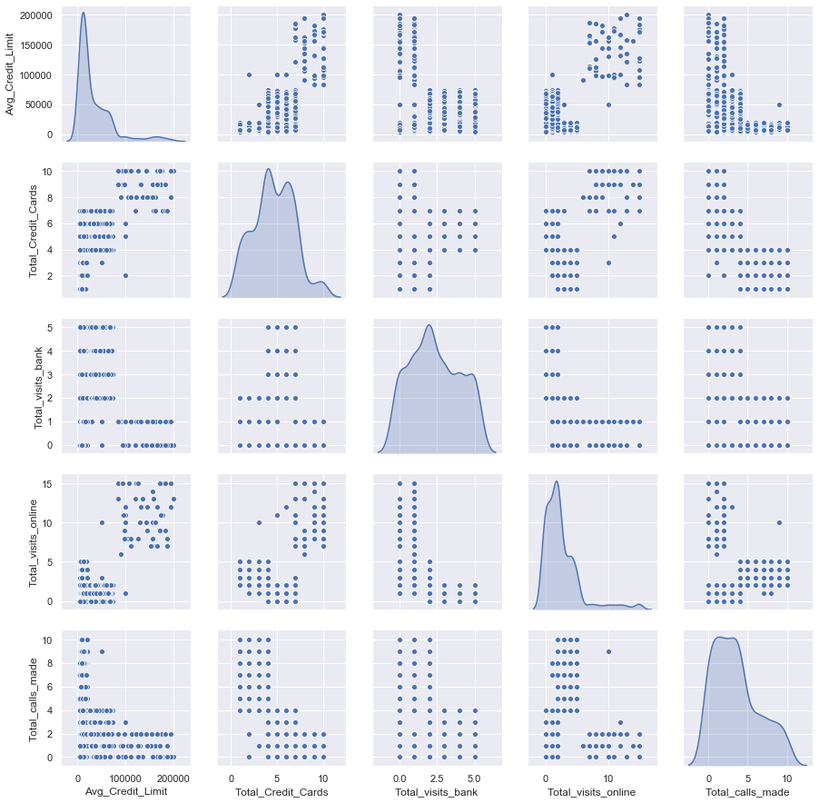

```python
# Lets generate pair plot to visualize the relationship among different features
sns.pairplot(ccdata, diag_kind='kde');
```

```python
# Let's calculate correlation among different features
ccdata.corr()
```

|  | Avg_Credit_Limit | Total_Credit_Cards | Total_visits_bank | Total_visits_online | Total_calls_made |
| --- | --- | --- | --- | --- | --- |
| Avg_Credit_Limit | 1.000000 | 0.608860 | -0.100312 | 0.551385 | -0.414352 |
| Total_Credit_Cards | 0.608860 | 1.000000 | 0.315796 | 0.167758 | -0.651251 |
| Total_visits_bank | -0.100312 | 0.315796 | 1.000000 | -0.551861 | -0.506016 |
| Total_visits_online | 0.551385 | 0.167758 | -0.551861 | 1.000000 | 0.127299 |
| Total_calls_made | -0.414352 | -0.651251 | -0.506016 | 0.127299 | 1.000000 |

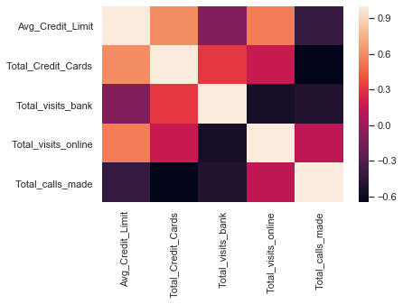

```python
# Let's generate heatmap to visulize correlation
sns.heatmap(ccdata.corr());
```

Looking at the pair plot, correlation metrics and heatmap, we can observe that there is some relationship is going on among different features

1) The average credit limit increases with total credit cards

2) Average credit limit also increases for users who make more online visits

3) User who makes more call, tend to have less credit cards

4) User who makes more visit to bank, tend to have less calls made to bank, which seems obvious.

5) Looking at the pair plot, it seems there could be 4 or 5 ideal number of clusters. We will see as we progress with analysis

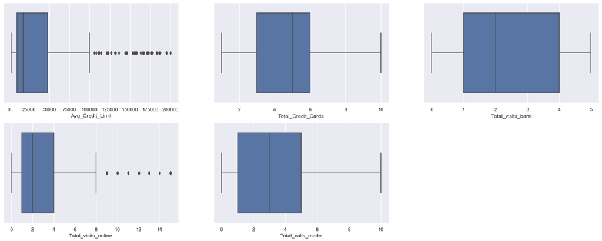

```python
# Let's generate the boxplot to see outliers
rowCnt = len(ccdata.columns)
colCnt = 3     # cols:  OVERALL, NO DISEASE, DISEASE
subCnt = 1     # initialize plot number

fig = plt.figure(figsize=(24,24))

for i in ccdata.columns:
    plt.subplot(rowCnt, colCnt, subCnt)
    #plt.title('OVERALL (row{},col{},#{})'.format(rowCnt, colCnt, subCnt), fontsize=14)
    plt.xlabel(i, fontsize=12)
    sns.boxplot(ccdata[i])
    subCnt = subCnt + 1

plt.show()
```

We can observe that average credit limits and total visit online has some outliers. We can use advance clustering techniques such DBSCAN, which will take care of outliers autometically.

As we noticed eariler that scale for average credit limit is much higher then scale for rest of the features hence it will dominate the analysis. We need to scale the features to avoid this issue due to scale of average credit limit feature

```python
# Let's scale data to bring all features on similar scale
sdata = ccdata.apply(zscore)
```

```python
sdata.head()
```

| Sl_No | Avg_Credit_Limit | Total_Credit_Cards | Total_visits_bank | Total_visits_online | Total_calls_made |
| --- | --- | --- | --- | --- | --- |
| 1 | 1.740187 | -1.249225 | -0.860451 | -0.547490 | -1.251537 |
| 2 | 0.410293 | -0.787585 | -1.473731 | 2.520519 | 1.891859 |
| 3 | 0.410293 | 1.058973 | -0.860451 | 0.134290 | 0.145528 |
| 4 | -0.121665 | 0.135694 | -0.860451 | -0.547490 | 0.145528 |
| 5 | 1.740187 | 0.597334 | -1.473731 | 3.202298 | -0.203739 |

Now our final dataset is ready and we are all set to start develop ML models using clustering techniques

### K-Means Clustering: Create appropriate clusters with the scaled data set

In order to implement the K-Means clustering, we need to find the optimal number of clusters in which customers will be placed. To find the optimal number of clusters for K-Means, the Elbow method is used based on Within-Cluster-Sum-of-Squares (WCSS) error

```python
cluster_range = range(1,15)
cluster_errors = []

for i in cluster_range:
    clusters = KMeans(n_clusters=i, n_init=5)
    clusters.fit(sdata)
    labels = clusters.labels_
    centroids = clusters.cluster_centers_        # Coordinates of cluster centers
    cluster_errors.append(clusters.inertia_)     # Sum of squared distances of samples to their closest cluster center

clusters_df = pd.DataFrame({"num_clusters": cluster_range, "cluster_errors": cluster_errors})
clusters_df[0:15]
```

|  | num_clusters | cluster_errors |
| --- | --- | --- |
| 0 | 1 | 3300.000000 |
| 1 | 2 | 2040.989816 |
| 2 | 3 | 933.043749 |
| 3 | 4 | 780.773690 |
| 4 | 5 | 738.112683 |
| 5 | 6 | 642.372555 |
| 6 | 7 | 613.259935 |
| 7 | 8 | 563.286614 |
| 8 | 9 | 544.355234 |
| 9 | 10 | 518.284097 |
| 10 | 11 | 488.065998 |
| 11 | 12 | 467.932625 |
| 12 | 13 | 446.186078 |
| 13 | 14 | 428.816494 |

### Lets tdentify the appropriate clusters with result from previous step

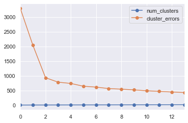

```python
clusters_df.plot(marker = "o");
```

```python
kmeans = KMeans(n_clusters=2, n_init = 5, random_state=3)
kmeans.fit(sdata)

# Check the number of data in each cluster

labels = kmeans.labels_
pd.Series(labels).value_counts()
```

```
0    436
1    224
dtype: int64
```

```python
# Let's check the centroid in each cluster

centroids = kmeans.cluster_centers_
centroid_df = pd.DataFrame(centroids, columns = list(sdata) )
centroid_df.transpose()
```

|  | 0 | 1 |
| --- | --- | --- |
| Avg_Credit_Limit | 0.306097 | -0.595796 |
| Total_Credit_Cards | 0.544393 | -1.059623 |
| Total_visits_bank | 0.463165 | -0.901518 |
| Total_visits_online | -0.165943 | 0.322997 |
| Total_calls_made | -0.589854 | 1.148109 |

1) Customers in group 0 have higher average credit limit, higher number of credit cards and these customer made lowest number of calls to the bank

2) Customers in group 1 made higher number of calls to the bank and also has less number of credit card

### Let's assgin these group to original data set for further analysis

```python
predictions = kmeans.predict(sdata)
```

```python
# Add label into scaled data
sdata["group"] = predictions
sdata['group'] = sdata['group'].astype('category')

# Add labels into original data
ccdata["group"] = predictions
ccdata['group'] = ccdata['group'].astype('category')
```

```python
ccdata.head()
```

| Sl_No | Avg_Credit_Limit | Total_Credit_Cards | Total_visits_bank | Total_visits_online | Total_calls_made | group |
| --- | --- | --- | --- | --- | --- | --- |
| 1 | 100000 | 2 | 1 | 1 | 0 | 0 |
| 2 | 50000 | 3 | 0 | 10 | 9 | 1 |
| 3 | 50000 | 7 | 1 | 3 | 4 | 0 |
| 4 | 30000 | 5 | 1 | 1 | 4 | 0 |
| 5 | 100000 | 6 | 0 | 12 | 3 | 0 |

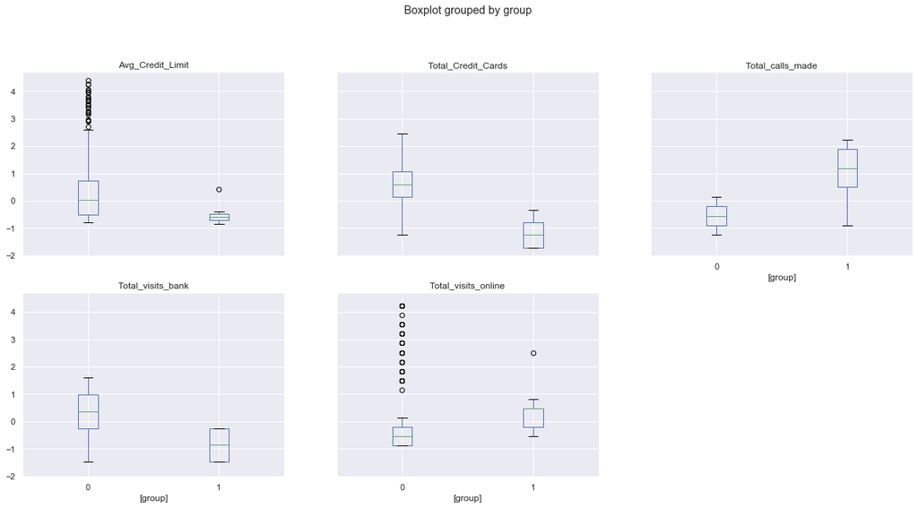

```python
sdata.boxplot(by = 'group',  layout=(3,3), figsize=(20, 15));
```

```python
ccdatabygrp = ccdata.groupby('group').sum()
```

```python
ccdatabygrp
```

| group | Avg_Credit_Limit | Total_Credit_Cards | Total_visits_bank | Total_visits_online | Total_calls_made |
| --- | --- | --- | --- | --- | --- |
| 0 | 20092000 | 2566 | 1377 | 924 | 826 |
| 1 | 2727000 | 540 | 209 | 796 | 1539 |

1) We can observe that group 0 has customers who have high average credit limit, high number of credit cards and make more visits to the bank.

2) Group 1 low creadit limit, has less number of credit cards and makes so many call to the bank

```python
# Calculate Silhoutte Score

from sklearn.metrics import silhouette_score
sscore_km = silhouette_score(sdata,predictions)
sscore_km
```

```
0.44480554353718277
```

Silhouette Score is better when closer to 1 and worse when closer to -1

We got 0.44 score, which is not so great

I experimented with cluster = 5 and got Silhouette Score = 0.57, which is better then with cluster = 2

## Let's implement hierarchical clustering and analyze appropriate clusters

In K-Means, we used elbow method to come up with optimal number of cluster. We will use dendogram to get optimal number of clusters in hierarchical clustering.

```python
sdata.head()
```

| Sl_No | Avg_Credit_Limit | Total_Credit_Cards | Total_visits_bank | Total_visits_online | Total_calls_made | group |
| --- | --- | --- | --- | --- | --- | --- |
| 1 | 1.740187 | -1.249225 | -0.860451 | -0.547490 | -1.251537 | 0 |
| 2 | 0.410293 | -0.787585 | -1.473731 | 2.520519 | 1.891859 | 1 |
| 3 | 0.410293 | 1.058973 | -0.860451 | 0.134290 | 0.145528 | 0 |
| 4 | -0.121665 | 0.135694 | -0.860451 | -0.547490 | 0.145528 | 0 |
| 5 | 1.740187 | 0.597334 | -1.473731 | 3.202298 | -0.203739 | 0 |

```python
# Let's drop 'group' column from original dataset and scaled dataset for further analysis
ccdata.drop('group', axis=1, inplace=True)
sdata.drop('group', axis=1, inplace=True)
```

```python
ccdata.head()
sdata.head()
```

| Sl_No | Avg_Credit_Limit | Total_Credit_Cards | Total_visits_bank | Total_visits_online | Total_calls_made |
| --- | --- | --- | --- | --- | --- |
| 1 | 1.740187 | -1.249225 | -0.860451 | -0.547490 | -1.251537 |
| 2 | 0.410293 | -0.787585 | -1.473731 | 2.520519 | 1.891859 |
| 3 | 0.410293 | 1.058973 | -0.860451 | 0.134290 | 0.145528 |
| 4 | -0.121665 | 0.135694 | -0.860451 | -0.547490 | 0.145528 |
| 5 | 1.740187 | 0.597334 | -1.473731 | 3.202298 | -0.203739 |

### Let's create dendogram to visualize the clusters and identify appropriate clusters with the help of dendrogram and cophenetic coeff.

```python
from scipy.cluster.hierarchy import cophenet, dendrogram, linkage
from scipy.spatial.distance import pdist  #Pairwise distribution between data points
```

```
Cophenetic coeff. for average method: 0.8977080867389372
```

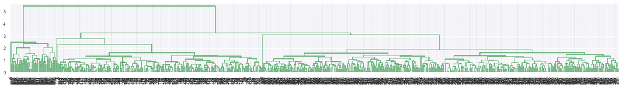

```
Cophenetic coeff. for complete method: 0.8599730607972423
```

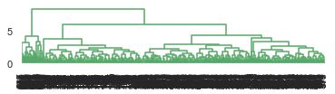

```
Cophenetic coeff. for ward method: 0.7415156284827493
```

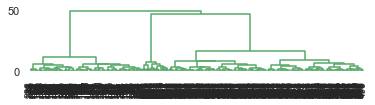

```python
# cophenet index is a measure of the correlation between the distance of points in feature space and distance on dendrogram
# closer it is to 1, the better is the clustering

method_name = ['average', 'complete', 'ward']
plot_number = 1
plt.figure(figsize=(25, 10))
for mname in method_name:
    Z = linkage(sdata, metric='euclidean', method=mname)
    c, coph_dists = cophenet(Z , pdist(sdata))
    print('Cophenetic coeff. for',mname,'method:',c)
    plt.subplot(3, 1, plot_number)
    dendrogram(Z, leaf_rotation=90.,color_threshold=90,  leaf_font_size=10)
    plt.show()
    plot_number = plot_number+1
```

```python
print('Shape of Z: ',Z.shape)
print('Linkage Merics: ',Z)
print('Coph Distance: ',coph_dists)
```

```
Shape of Z:  (659, 4)
Linkage Merics:  [[ 464.          497.            0.            2.        ]
 [ 425.          455.            0.            2.        ]
 [ 250.          361.            0.            2.        ]
 ...
 [1313.         1314.           16.84480374  385.        ]
 [1311.         1316.           47.06715339  435.        ]
 [1315.         1317.           50.16298666  660.        ]]
Coph Distance:  [50.16298666  6.4228412   6.81290874 ...  7.79653157  1.62874841
  7.79653157]
```

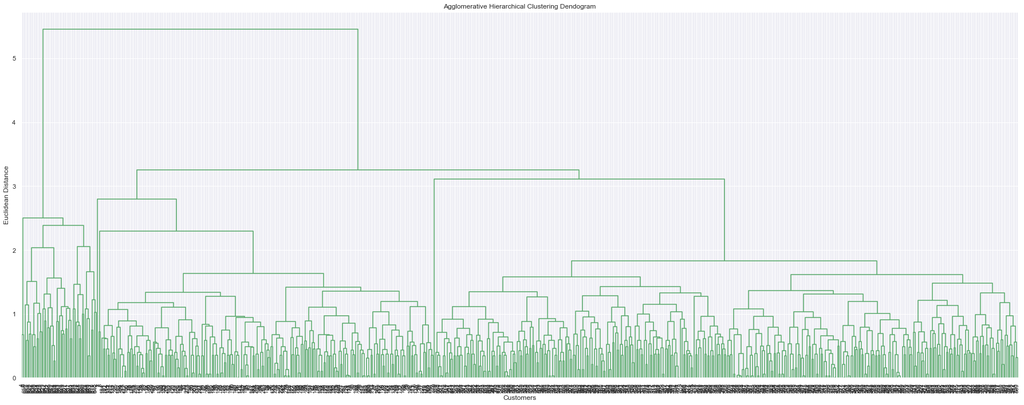

```python
# We noticed that average method provides best value for Cophenetic coeff. hence lets create dendogram with average method

Z = linkage(sdata, metric='euclidean', method='average')
c, coph_dists = cophenet(Z , pdist(sdata))

plt.figure(figsize=(25, 10))
plt.title('Agglomerative Hierarchical Clustering Dendogram')
plt.xlabel('Customers')
plt.ylabel('Euclidean Distance')
dendrogram(Z, leaf_rotation=90.,color_threshold=90,  leaf_font_size=10. )
plt.tight_layout()
```

### Create truncated dendrogram with last p merged clusters, find out the optimal distance between clusters which u want to use an input for clustering data

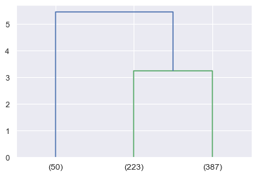

```python
# Use truncate_mode='lastp' attribute in dendrogram function to arrive at dendrogram
dendrogram(
    Z,
    truncate_mode='lastp',  # show only the last p merged clusters
    p=3,  # show only the last p merged clusters
)
plt.show()
```

```python
max_d = 3.3
```

### Use this distance measure(max_d) and fcluster function to cluster the data into 2 different groups

```python
from scipy.cluster.hierarchy import fcluster
clusters = fcluster(Z, max_d, criterion='distance')
pd.Series(clusters).nunique()
```

```
2
```

```python
# Calculate Average Silhoutte Score

silhouette_score(sdata,clusters)
```

```
0.5703183487340514
```

We got best Silhoutte Score with 2 clusters

### Now we train the hierarchical clustering algorithm and predict the cluster for each data point

```python
from sklearn.cluster import AgglomerativeClustering
```

```python
model = AgglomerativeClustering(n_clusters=2, affinity='euclidean',  linkage='average')
predcition_hc = model.fit_predict(sdata)
```

```python
# Let's add the label generated back to original dataset
ccdata['group'] = predcition_hc
ccdata.head()
```

| Sl_No | Avg_Credit_Limit | Total_Credit_Cards | Total_visits_bank | Total_visits_online | Total_calls_made | group |
| --- | --- | --- | --- | --- | --- | --- |
| 1 | 100000 | 2 | 1 | 1 | 0 | 0 |
| 2 | 50000 | 3 | 0 | 10 | 9 | 0 |
| 3 | 50000 | 7 | 1 | 3 | 4 | 0 |
| 4 | 30000 | 5 | 1 | 1 | 4 | 0 |
| 5 | 100000 | 6 | 0 | 12 | 3 | 1 |

```python
ccdatabygrp_agg = ccdata.groupby('group').sum()
ccdatabygrp_agg
```

| group | Avg_Credit_Limit | Total_Credit_Cards | Total_visits_bank | Total_visits_online | Total_calls_made |
| --- | --- | --- | --- | --- | --- |
| 0 | 15767000 | 2669 | 1556 | 1175 | 2311 |
| 1 | 7052000 | 437 | 30 | 545 | 54 |

```python
# Calculate Average Silhoutte Score

sscore_hc = silhouette_score(sdata,predcition_hc)
print('Average Silhoutte Score for K-Means Clustering: ',sscore_km)
print()
print('Average Silhoutte Score for hierarchical clustering : ',sscore_hc)
```

```
Average Silhoutte Score for K-Means Clustering:  0.44480554353718277

Average Silhoutte Score for hierarchical clustering :  0.5703183487340514
```

We are able to get better Silhoutte Score with hierarchical clustering with same dataset

### Compare K-Means clusters with Hierarchical clusters

#### K-Means clustering and hierarchical clustering (HC) both share many similarities. Despite that, there are few key differences as well:

1) Techniques for finding optimum number of clusters: K-Means provides Elbow method whereas HC provides dendogram to get the optimum number of clusters.

2) We need to prescribe the number of clusters to get to the stage where we can use Elbow method to get optimum number of clusters however in case of HC, we discover number of optimum clsuters.

3) In case of current dataset HC provided better Silhoutte Score then K-Means.

4) K-Means is based on partition and centroid based approach whereas HC based on hierarchy/tree based approach.

5) K-Means is better option in case of large number of features in the dataset. As you can observe, the plot we used for elbow method, is a simple curve irrespective of number of features whereas dendogram for HC shows so many clusters in the bottom of the dendogram and as number of features increases, it will become even more complicated therefore it will be challanging to visualize the dendogram completely when dataset contains large number of features.